# Cars: MPG vs. Transmission Type

Samuel Shaw

10/19/2017

## Summary

Does the distance a car can drive on a gallon of gas (miles per gallon, MPG) depend on wether or not the car has an automatic or manual transmission? Looking at R’s data on different types of cars (datasets::mtcars), we can quantify the MPG difference in manual vs. automatic transmission vehicles, and we can do so while accounting for other confounding variables. I find that transmission type does correspond to a significant MPG difference, but when accounting for the vehicles weight, horsepower, and number of cylinders, the transmission effect goes away.

## Data and Method

```r
library(datasets)
str(mtcars)
```

```
## 'data.frame':    32 obs. of  11 variables:
##  $ mpg : num  21 21 22.8 21.4 18.7 18.1 14.3 24.4 22.8 19.2 ...
##  $ cyl : num  6 6 4 6 8 6 8 4 4 6 ...
##  $ disp: num  160 160 108 258 360 ...
##  $ hp  : num  110 110 93 110 175 105 245 62 95 123 ...
##  $ drat: num  3.9 3.9 3.85 3.08 3.15 2.76 3.21 3.69 3.92 3.92 ...
##  $ wt  : num  2.62 2.88 2.32 3.21 3.44 ...
##  $ qsec: num  16.5 17 18.6 19.4 17 ...
##  $ vs  : num  0 0 1 1 0 1 0 1 1 1 ...
##  $ am  : num  1 1 1 0 0 0 0 0 0 0 ...
##  $ gear: num  4 4 4 3 3 3 3 4 4 4 ...
##  $ carb: num  4 4 1 1 2 1 4 2 2 4 ...
```

The mtcars dataset was extracted from the 1974 Motor Trend US magazine, and comprises fuel consumption and 10 aspects of automobile design and performance for 32 automobiles (1973–74 models) (R Package: datasets, Version 3.4.1). Categorical variables are recoded for later analyses.

```r
mtcars$am<-factor(mtcars$am)
levels(mtcars$am)<-c("Automatic", "Manual")
mtcars$cyl<-factor(mtcars$cyl)
levels(mtcars$cyl)<-c("4cyl", "6cyl", "8cyl")
mtcars$vs<-factor(mtcars$vs)
levels(mtcars$vs)<-c("V-shape", "Straight")
mtcars$gear<-factor(mtcars$gear)
levels(mtcars$vs)<-c("3", "4", "5")
mtcars$carb<-factor(mtcars$carb)
levels(mtcars$carb)<-c("1", "2", "3", "4", "5", "6", "7", "8")
```

In the following analyses, I will analyze the effect of transmission type on mileage using bivariate and multivariate statistics. Standard OLS linear regression allows for testing the effect of transmission on mileage while holding other variables constant. Further, analysis of model variance allows for understanding the best model fit, and a discussion of the model’s residuals will show us if the model is an appropriate analytical tool.

## Miles per Gallon vs. Transmission Type

```r
summary(mtcars$mpg)
```

```
##    Min. 1st Qu.  Median    Mean 3rd Qu.    Max.
##   10.40   15.43   19.20   20.09   22.80   33.90
```

```r
table(mtcars$am)
```

```
##
## Automatic    Manual
##        19        13
```

The milage of the 32 cars in the dataset range from 10.4 to 33.9, with an average MPG of 20.1. Nineteen of these cars have an automatic transmission and thirteen are manual.

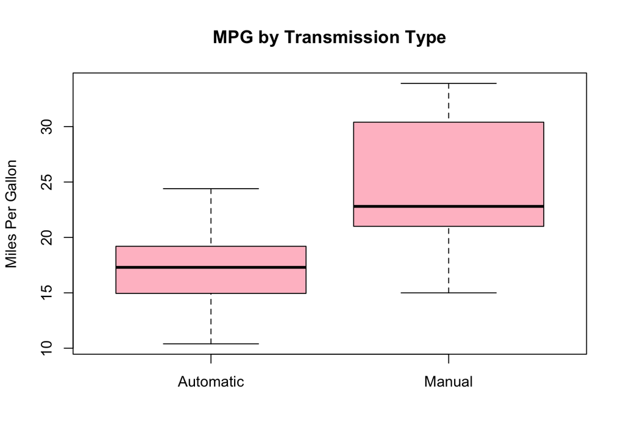

```r
boxplot(mpg~am, data=mtcars, ylab="Miles Per Gallon", main="MPG by Transmission Type", col="pink")
```

The side-by-side box plot above demonstrates an obvious variation in milage when comparing manual to automatic transmission cars.

```r
t.test(mpg~am, data=mtcars)
```

```
##
##  Welch Two Sample t-test
##
## data:  mpg by am
## t = -3.7671, df = 18.332, p-value = 0.001374
## alternative hypothesis: true difference in means is not equal to 0
## 95 percent confidence interval:
##  -11.280194  -3.209684
## sample estimates:
## mean in group Automatic    mean in group Manual
##                17.14737                24.39231
```

Indeed, we can infer from the t-test above that milage is related to transmission type. The difference in means (7.24 MPG) is large enough to conclude that there is very little chance (p = .001) that the observed difference is likely to occur by noise in the data alone. Based on bivariate statistics alone, we would reject the null hypothesis and conclude that manual transmissions get better gas mileage (in 1974 at least).

To fully assess whether transmission type is a significant determinant of gas mileage, however, we must account for possible confounding variables. That is, transmission type may be related to other factors, such as engine size, weight, or horsepower, each of which may better explain variation in gas mileage.

## Multiple Regression Analysis

In fact, every other variable included in the dataset has a statistically significant relationship to a car’s MPGs (see Appendix, below). Below, I regress each variable on gas mileage simultaneously, so that we can see the effect of each, holding each other constant. Note: I omit the car’s 1/4 mile time because this variable is, like MPG, a performance measure, so it would seem likely that they are spurriously correlated; I also omit the variable gear, because gear number is correlated to transmission type by design.

```r
fullmodel<-lm(mpg~am+cyl+disp+hp+drat+wt+vs+carb, data=mtcars); # i.e, full without qsec and gears
summary(fullmodel)
```

```
##
## Call:
## lm(formula = mpg ~ am + cyl + disp + hp + drat + wt + vs + carb,
##     data = mtcars)
##
## Residuals:
##     Min      1Q  Median      3Q     Max
## -3.7086 -1.4119  0.0302  0.7624  4.3994
##
## Coefficients:
##             Estimate Std. Error t value Pr(>|t|)
## (Intercept) 28.86269   10.94309   2.638   0.0167 *
## amManual     1.60639    2.04356   0.786   0.4421
## cyl6cyl     -3.14936    2.53987  -1.240   0.2309
## cyl8cyl     -2.32360    5.09121  -0.456   0.6536
## disp         0.03556    0.02660   1.337   0.1980
## hp          -0.06604    0.03102  -2.129   0.0473 *
## drat         1.50319    2.23163   0.674   0.5091
## wt          -4.23798    2.04813  -2.069   0.0532 .
## vs4          2.38609    2.36209   1.010   0.3258
## carb2       -0.45802    1.65845  -0.276   0.7856
## carb3        3.58575    3.88249   0.924   0.3679
## carb4        1.10296    3.42655   0.322   0.7512
## carb5        5.07957    5.60594   0.906   0.3769
## carb6        8.08435    7.32199   1.104   0.2841
## ---
## Signif. codes:  0 '***' 0.001 '**' 0.01 '*' 0.05 '.' 0.1 ' ' 1
##
## Residual standard error: 2.642 on 18 degrees of freedom
## Multiple R-squared:  0.8884, Adjusted R-squared:  0.8079
## F-statistic: 11.03 on 13 and 18 DF,  p-value: 4.8e-06
```

The full model summary tells us that, controlling for other factors, the effect of transmission type on gas mileage all but dissapears. The effect is still positive (manual transmission cars get a mean 1.6 MPGs better than automatics, instead of 7.24), but it is no longer statistically significant (p = .44), and so we cannot conclude that the difference is not due to random chance. In fact, in the full model, we see very little statistically significant correlates to mpg. Only horsepower is signficantly related. A one unit increase in horsepower leads to a decrease in .06 miles to the gallon, holding every other variable constant.

### Model Selection

It should not be surprising that we see few significant predictors of mpg, however, because our n is so small; we have a tiny number of cases for each indpendent variable. We can look for a better explanatory model whose least squares minimize the variance. The R function step(), below, calculates the variances of models of multiple smaller combinations of variables included in our original full model.

```r
best<-step(fullmodel, direction="both"); # hidden to save space
```

```r
summary(best)
```

```
##
## Call:
## lm(formula = mpg ~ am + cyl + hp + wt, data = mtcars)
##
## Residuals:
##     Min      1Q  Median      3Q     Max
## -3.9387 -1.2560 -0.4013  1.1253  5.0513
##
## Coefficients:
##             Estimate Std. Error t value Pr(>|t|)
## (Intercept) 33.70832    2.60489  12.940 7.73e-13 ***
## amManual     1.80921    1.39630   1.296  0.20646
## cyl6cyl     -3.03134    1.40728  -2.154  0.04068 *
## cyl8cyl     -2.16368    2.28425  -0.947  0.35225
## hp          -0.03211    0.01369  -2.345  0.02693 *
## wt          -2.49683    0.88559  -2.819  0.00908 **
## ---
## Signif. codes:  0 '***' 0.001 '**' 0.01 '*' 0.05 '.' 0.1 ' ' 1
##
## Residual standard error: 2.41 on 26 degrees of freedom
## Multiple R-squared:  0.8659, Adjusted R-squared:  0.8401
## F-statistic: 33.57 on 5 and 26 DF,  p-value: 1.506e-10
```

R’s step() function returns the model that says (which represents the least residual variance): Gas milage is a function of transmission type, number of cylinders, horsepower, and the vehicle’s weight. Compared to the full model, we see that vehicle weight now seems to be the strongest predictor of gas mileage, while horsepower, and number of cylinders (specifically the difference between 4 and 6 cylinders) also have significant effects. Transmission type, although it is included in our model, remains statistically insignificant, and so we cannot reject the null hypothesis: we cannot conclude that manual transmission vehicles get better gas mileage.

### Residual Diagnostics

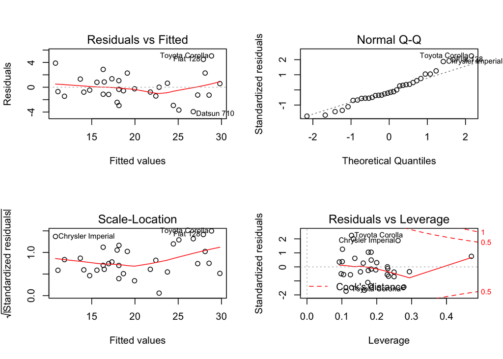

```r
par(mfrow=c(2,2))
plot(best)
```

### Appendix

The dataset includes 32 observations and the following variables:

mpg Miles/(US) gallon cyl Number of cylinders disp Displacement (cu.in.) hp Gross horsepower drat Rear axle ratio wt Weight (1000 lbs) qsec 1/4 mile time vs V/S am Transmission (0 = automatic, 1 = manual) gear Number of forward gears carb Number of carburetors (R Package: datasets, Version 3.4.1)

### Other correlations

```r
# Vehicle weight
with(mtcars, cor.test(mpg, wt))[4:3]
```

```
## $estimate
##        cor
## -0.8676594
##
## $p.value
## [1] 1.293959e-10
```

```r
# Horsepower
with(mtcars, cor.test(mpg, hp))[4:3]
```

```
## $estimate
##        cor
## -0.7761684
##
## $p.value
## [1] 1.787835e-07
```

```r
# Displacement
with(mtcars, cor.test(mpg, disp))[4:3]
```

```
## $estimate
##        cor
## -0.8475514
##
## $p.value
## [1] 9.380327e-10
```

```r
# Rear axle ratio
with(mtcars, cor.test(mpg, drat))[4:3]
```

```
## $estimate
##       cor
## 0.6811719
##
## $p.value
## [1] 1.77624e-05
```

```r
# 1/4 mile time
with(mtcars, cor.test(mpg, qsec))[4:3]
```

```
## $estimate
##      cor
## 0.418684
##
## $p.value
## [1] 0.01708199
```

```r
# V/S (shape of engine)
t.test(mpg~vs, data=mtcars)[3]
```

```
## $p.value
## [1] 0.0001098368
```

```r
# Number of cylinders
summary(lm(mpg~cyl, data=mtcars))$coef
```

```
##               Estimate Std. Error   t value     Pr(>|t|)
## (Intercept)  26.663636  0.9718008 27.437347 2.688358e-22
## cyl6cyl      -6.920779  1.5583482 -4.441099 1.194696e-04
## cyl8cyl     -11.563636  1.2986235 -8.904534 8.568209e-10
```

```r
# Number of gears
summary(lm(mpg~gear, data=mtcars))$coef
```

```
##              Estimate Std. Error   t value     Pr(>|t|)
## (Intercept) 16.106667   1.215611 13.249852 7.867272e-14
## gear4        8.426667   1.823417  4.621361 7.257382e-05
## gear5        5.273333   2.431222  2.169005 3.842222e-02
```

```r
# Number of carburetors
summary(lm(mpg~carb, data=mtcars))$coef
```

```
##               Estimate Std. Error   t value     Pr(>|t|)
## (Intercept)  25.342857   1.853844 13.670438 2.214664e-13
## carb2        -2.942857   2.417117 -1.217507 2.343463e-01
## carb3        -9.042857   3.384640 -2.671734 1.284993e-02
## carb4        -9.552857   2.417117 -3.952170 5.295477e-04
## carb5        -5.642857   5.243462 -1.076170 2.917362e-01
## carb6       -10.342857   5.243462 -1.972524 5.927269e-02
```